[figure not shown]

# Federal Funds Tracker

The Recovery Funds Dashboard tracks a subset of the federal recovery funds flowing from the Coronavirus Aid, Relief, and Economic Security Act (CARES), the Consolidated Appropriations Act 2021 (CRRSAA), and the American Rescue Plan Act (ARPA) into Chicago, Cook County, and the State of Illinois.

The Infrastructure Funds Dashboard tracks federal funding flowing from the Infrastructure Investment and Jobs Act (IIJA) to all recipients in the Chicago area.

# Total Dollars Tracked

## By Legislation

[figure not shown]

## By Recipient

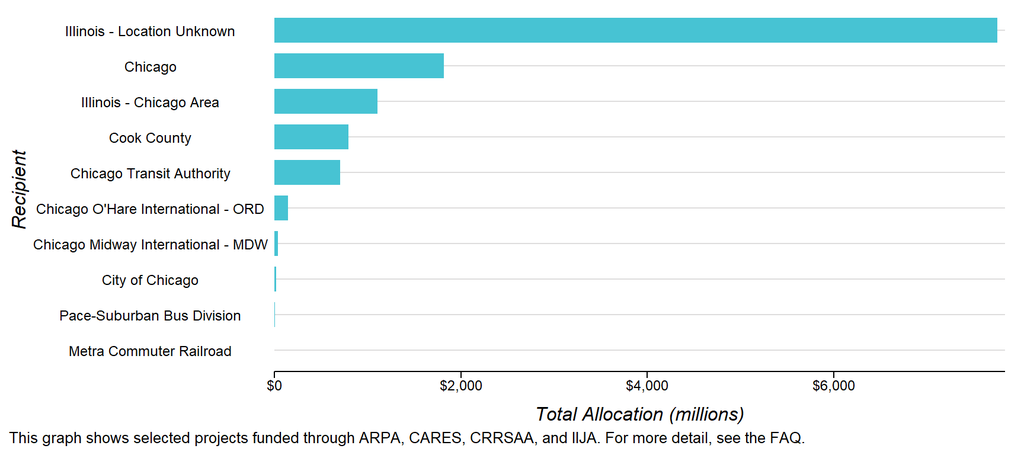

# About the Dashboard

The inclusive recovery funds we track represent a subset of COVID-19 assistance provided by the federal government. The dashboard only reflects funds flowing directly from the federal government to the State of Illinois, Cook County, and the City of Chicago that can be used for inclusive recovery efforts that align with key priorities of The Chicago Community Trust: community investment, community safety, household investment, housing, and workforce development, which are all vital to narrowing the Chicago region’s racial and ethnic wealth gap. It does not include funds provided by the federal government directly to public housing authorities, school districts, universities, or nongovernmental organizations, such as non-profits or private sector firms.

[Download all the data used in the dashboard (.zip)](https://federal-funds-equity.s3.amazonaws.com/all_programs_total.zip)

This project is a collaboration between [The Chicago Community Trust](https://www.cct.org/) and the [Urban Institute](https://www.urban.org/). It is supported by a grant from the Kresge Foundation through the [Shared Prosperity Partnership](http://www.sharedprosperitypartnership.org/).

Please contact Aimee Ramirez (The Chicago Community Trust) and Karolina Ramos (Urban Institute) with questions.

The code used to create this dashboard can be found on [GitHub](https://github.com/Chi-Trust/Recovery-Funds-Dashboard).